# Part II - Effect of User Type and Days of Week on Bike Trips

## by Adewale Olayemi

## Investigation Overview

In this investigation, the main focus is on the user type and days of the week features. I will be looking at how these two variable affect the number of bike trips and the time spent on riding bike.

## Dataset Overview

The dataset used for this project consist of 519700 bike trips made between June 2017 to December 2017. The dataset was provided by Ford GoBike, a bike sharing system covering the greater San Francisco Bay area. Some of the variables in the dataset includes trip duration, user type, start and end station, user gender, etc. I performed data wrangling on the dataset like assessing the data, changing data type, removing missing values, etc.

## Distribution of Users Age

The age distribution has a range of values from about 20 years old to 120 years old. Most the bike riders are between the age of 18 to 40 years, which may be considered as youths.

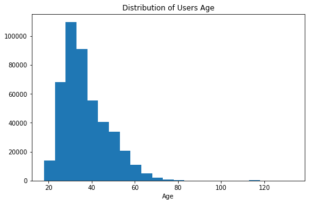

## Distribution of Rides by User Type

89.2% (404424) of the rides were made by the subscribers, while 10.8% (48735) were made by customers. This shows that most user prefer to register and pay for the monthly subscription fee.

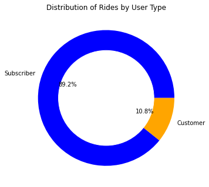

## Average Trip Duration By Users

Despite the fact that there are more subscribers than customers, customer spent more time in riding bike than subscribers. Customers has an average 31.5 minutes per trip, while subscribers has an average of 11.8 minutes per trip.

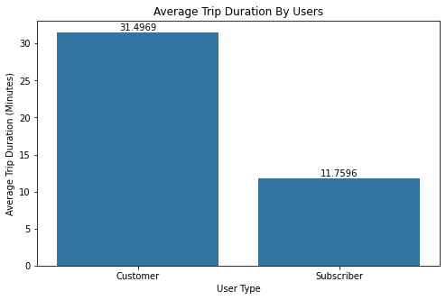

## Distribution of Rides by Days of the Week

There are more bike ride on weekdays (from Monday to Friday) and low number of bike rides on Saturday and Sunday. This shows that most users make use of bike ride for moving to their place of work.

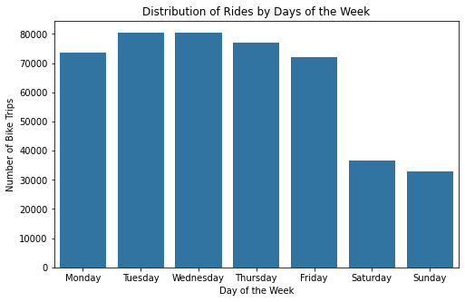

## Average Trip Duration By Days of the Week

Even though there are more trips during the weekdays, the average trip duration on weekdays was low, while the average trip duration was high during weekend (Saturday and Sunday).

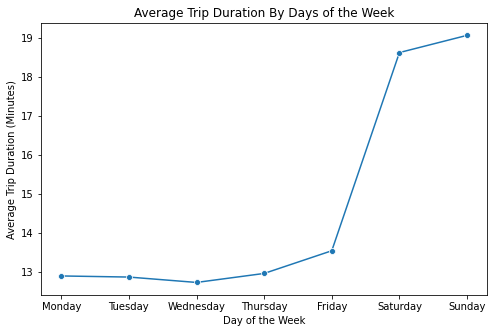